# Comparing representations

Technical clarifications · RSA and linear CKA

18 November 2026

## Same inputs, different features

$$X\in\mathbb R^{n\times p},\qquad Y\in\mathbb R^{n\times q}.$$

**Rows:** the same $n$ inputs, in the same order.  
**Columns:** features; $p$ and $q$ can differ.

All three methods compare relations **between inputs** within each space:

- RSA: dissimilarities $D^X_{ij}$ and $D^Y_{ij}$.
- Linear CKA: centered dot products $K_{ij}$ and $L_{ij}$.
- Mutual-kNN: neighbour sets $N^X_k(i)$ and $N^Y_k(i)$.

Feature coordinates need not match. **Input identities must.**

## Which changes should leave the score unchanged?

Linear CKA first centers each feature across the $n$ inputs.

| Change applied to one space | Same linear CKA? |
| --- | --- |
| Add a constant vector to every row | Yes: centering removes it |
| Rotate, reflect, permute features | Yes: dot products unchanged |
| Multiply all features by the same $c\neq 0$ | Yes: normalization cancels it |
| Stretch one feature or direction more | Generally no |

Any invertible linear map $A$ preserves linear predictions:  
if $X'=XA$, the readout $W'=A^{-1}W$ gives $X'W'=XW$.

**Linear predictability is preserved; distances and angles need not be.**

## Why CCA’s invariance goes too far

**CCA:** find linear combinations of $X$’s features and of $Y$’s features  
with maximal correlation.

An invertible $A$ leaves the set of available combinations unchanged, so CCA ignores it.

**Kornblith, Theorem 1.** $X,Y$ both $n\times p$ with rank $n$ ($p\ge n$). For any score $s$ invariant to all invertible maps:
$$s(X,Z)=s(Y,Z)\quad\text{for every } Z.$$

**Concretely for CCA:** after centering, both column spaces are all of $\{v:\mathbf 1^\top v=0\}$ once the rank is $n-1$.  
Then **every canonical correlation is 1**, even if $Y$ is unrelated to $X$.

Centered data have rank at most $n-1$: the same argument, within $\mathbf 1^\perp$.  
Rank matters, not width alone.

## Why CCA’s invariance goes too far: Intuition

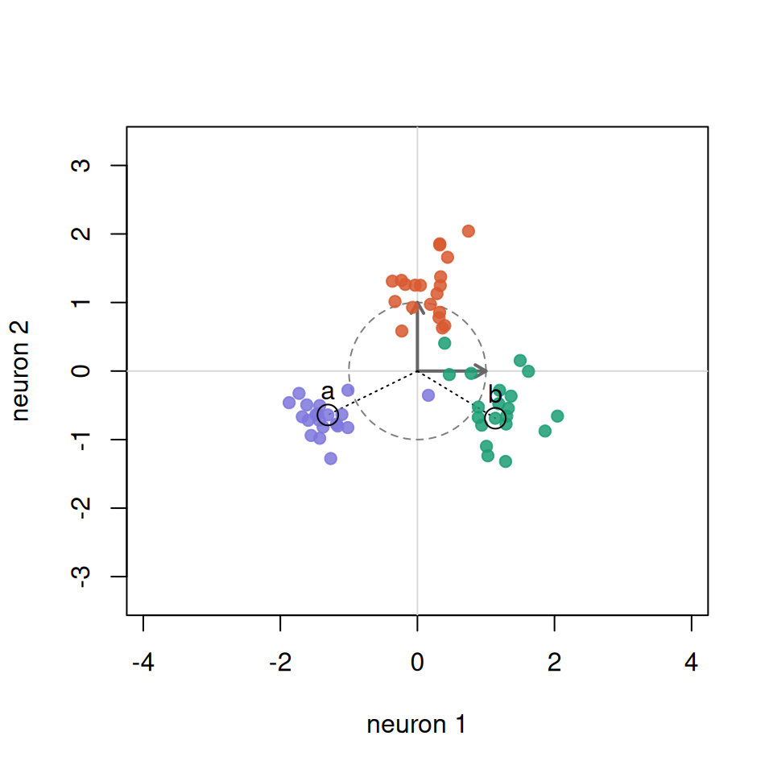

**Original** $X$.  
CKA 1.00 · CCA 1.00

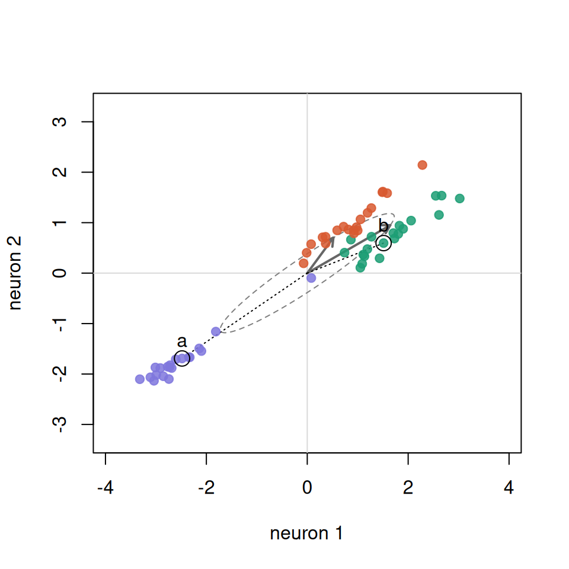

**Invertible** $A$: stretch + shear.  
CKA 0.85 · CCA 1.00

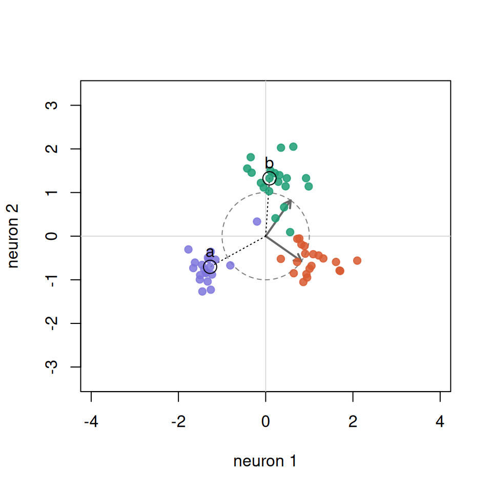

**Orthogonal** $A$: rotate + reflect.  
CKA 1.00 · CCA 1.00

## Linear CKA: a cosine between two matrices

Center the columns of $X,Y$; form $K=XX^\top$, $L=YY^\top$ ($n\times n$).

$$\operatorname{CKA}(X,Y)
=\frac{\langle K,L\rangle_F}{\|K\|_F\,\|L\|_F}
=\frac{\|X^\top Y\|_F^2}{\|X^\top X\|_F\,\|Y^\top Y\|_F}\ \in[0,1].$$

- **Input view:** $\langle K,L\rangle_F=\sum_{i,j}K_{ij}L_{ij}$, over all input pairs **including** $i=j$,  
  where $K_{ii}$ is input $i$’s squared distance from the centroid.
- **Feature view:** $\|X^\top Y\|_F^2=(n-1)^2\times$ sum of squared covariances between all features of $X$ and all features of $Y$.
- This is Kornblith’s Eq. 4 (normalized HSIC) with linear kernels.  
  Defined only if neither centered representation is identically zero.

## RSA: two different correlations

**1. Within each representation:** compare the activity patterns of inputs $i$ and $j$:

$$D^X_{ij}=1-\operatorname{corr}(x_i,x_j)\qquad\text{(correlation across features).}$$

Each pattern is centered and scaled **across its features** (CKA: each feature across inputs).  
So: unchanged if one input’s pattern is shifted or scaled; **changed** by rotating features.

**2. Between representations:** rank-correlate the entries above the diagonal:

$$s_{\mathrm{RSA}}=\rho_{\text{Spearman}}(d^X,d^Y),\quad\text{where } d^X=(D^X_{12},D^X_{13},\dots,D^X_{n-1,n}).$$

Correlation across **input pairs**.

Ranks: invariant to any monotone rescaling of the dissimilarities.  
The zero diagonal is not used.

## Permute labels, not distances

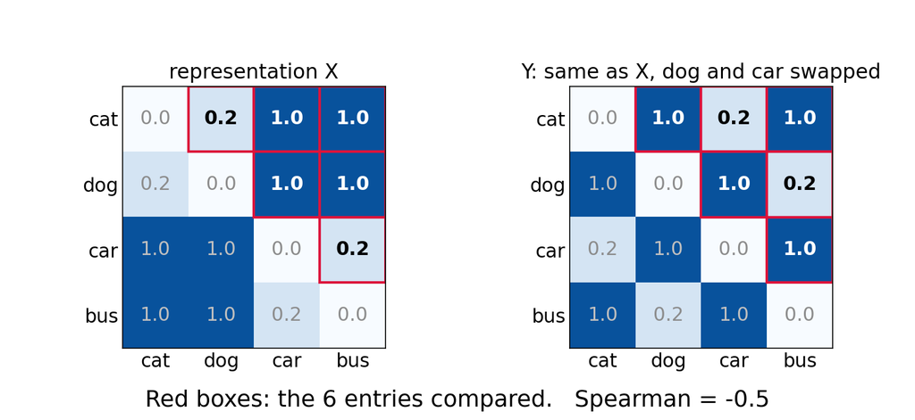

The six entries share inputs: cat–dog and cat–car both use **cat**.  
They are not six independent observations.

**Null:** relabel one representation with $\pi$ (same $\pi$ for rows and columns), recompute, repeat; compare the observed score with the upper tail.

## The permutation test: what it needs

**Exchangeable labels.** Permute only labels that are interchangeable under the null;  
repeated or grouped conditions need restricted permutations.

**Enough conditions.** Four conditions give only $4!=24$ relabelings: $p\ge 1/24$.  
The figure’s RDM: 8 relabelings leave it unchanged,  
so even perfect agreement has $p=8/24$.  
Kriegeskorte et al. use 96 conditions and 10,000 random relabelings.

**Searched over layers?** Apply each $\pi$ to the inputs of every layer of **one** model, keep the other fixed, take the maximum over all layer pairs: a null of maxima.

A small $p$ says the correspondence exceeds chance. It says nothing about the size or meaning of the agreement.

## Which questions do this week’s readings answer?

1. What are the rows, and do they correspond across spaces?
2. Which representation level or layer is compared?
3. What transformations leave the metric unchanged?
4. Is the claim global, local, or merely functional?
5. What score arises under a meaningful null?
6. Were layers, metrics, neighbourhood sizes, or model families selected after looking at the results?
7. Does the evidence justify convergence, or only above-chance agreement?

**Example claim** for the open questions:

> On 1,000 image–caption pairs, linear CKA between layer 9 of a vision model and layer 18 of a language model is **0.62**, the highest of all 12 × 24 layer pairs. Hence the two models share a representation.

## Local and global agreement can come apart

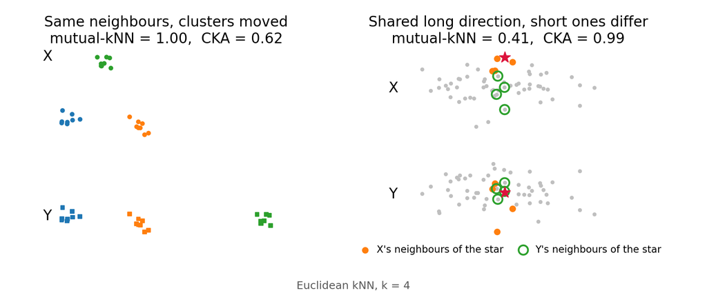

**Left:** every point keeps its neighbours, but the clusters move. Mutual-kNN is 1; CKA drops.  
**Right:** a shared high-variance direction drives CKA; small directions pick the neighbours.